# **Modeling and simulation (Week 1)**

- What is a system?
- What is a model?
- What is a simulation?
- What are discrete and continuous variables?
- What is the difference between deterministic and stochastic?

## **1D Random Walk**

A particle move in a 1D space: In one dimension the particle move up or down randomly with equal probability. The walks occurs for a given number of steps.

There is a reflecting barrier - if the particle collides with the reflecting barrier, the next step is up. There is also an absorbing barrier - if the particle collides with the abasorbing barrier the walk ends (the particle disappears).

[figure not shown]

The input (independent) variables of the system: this is how you set up your system.

The output (dependent) variables of the system: this is what you observe according to the system setup.

What type of system are you modeling/observing?

## **Continuous Uniform Distribution**

[figure not shown]

[Continuous uniform distribution](https://en.wikipedia.org/wiki/Continuous_uniform_distribution)

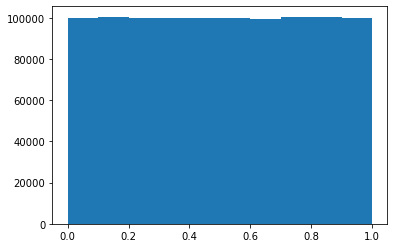

```python
import numpy as np
import matplotlib.pyplot as plt

h = plt.hist(np.random.random(size=1000000))
```

```python
(np.random.random(size=10) > 0.5).astype(int)
```

```
array([0, 0, 1, 1, 0, 0, 0, 1, 1, 0])
```

## **Assignments**

**Assignment 1**: Complete the code for the function that generates a number +1 or -1 with uniform probability.

```python
def random_value():

    # Genera un número aleatorio con distribución uniforme
    return np.random.choice([-1, 1])

random_value()
```

```
-1
```

**Assignment 2**: Complete the code for the function that generates a vector of N elements with +1 and -1 using a uniform distribution.

```python
def random_vector(N):

    # Genera un array con números aleatorios con distribución uniforme
    return np.random.choice([-1, 1], size = N)

random_vector(10)
```

```
array([ 1, -1,  1, -1, -1,  1,  1, -1, -1, -1])
```

We can use this code for visualizing a non-limited random walk.

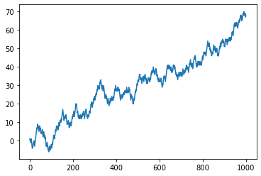

```python
p = plt.plot(random_vector(1000).cumsum())
```

**Assignment 3**: Complete the code for the function that generates a 1D random walk.

```
[0, 1, 0, 1, 2, 3, 2, 1, 0, 1, 2, 1, 0, 1, 2, 1, 2, 1, 2, 1, 0, 1, 2, 1, 2, 3, 4, 4]
```

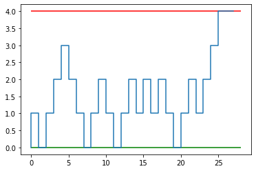

```python
def make_walk(absorbing_barrier, reflecting_barrier = 0, start = 0):

    current_index = 0
    end = False

    walk = [start]

    while end != True:

        # Si la partícula colisiona con la barrera reflectiva, el siguiente paso es 1
        if walk[current_index] == reflecting_barrier:
            walk.append(1)

        # Si la partícula colisiona con la barrera absorbente, el camino finaliza
        elif walk[current_index] == absorbing_barrier:
            walk.append(walk[current_index])
            end = True

        # Para cada paso se suma o resta 1 según la función de probabilidad uniforme
        else:
            walk.append(walk[current_index] + random_value())

        current_index += 1

    return walk

absorbing_barrier = 4
walk = make_walk(absorbing_barrier)

print(walk)

plt.hlines(0, 0, len(walk), colors='g')
plt.hlines(absorbing_barrier, 0, len(walk), colors='r')
s = plt.step(range(len(walk)), walk)
```

```python
walk = make_walk(absorbing_barrier)
print(walk, " - ", len(walk))
```

```
[0, 1, 2, 1, 2, 1, 0, 1, 2, 1, 0, 1, 2, 3, 4, 4]  -  16
```

**Assignment 4**: Complete the code for the function that computes the average walk for a given absorbing barrier.

```python
def average_steps(absorbing_barrier = 4, num_trials = 1000):

    # Crea un vector vacío de tamaño N
    len_walks = np.empty(num_trials, dtype=object)

    for i in range(num_trials):

        # Realiza una simulación del camino aleatorio en una dimensión
        walk = make_walk(absorbing_barrier)

        # Asigna la cantidad de pasos que le tomó llegar a la barrera absorbente
        len_walks[i] = len(walk)

    # Calcula el promedio
    value = (np.mean(len_walks)).astype(int)

    return value

average_steps(absorbing_barrier = 4, num_trials = 10000)
```

```
17
```

Let's compare with its theoretical average walk.

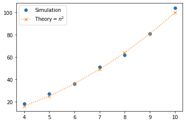

```python
n = np.array([4, 5, 6, 7, 8, 9, 10])
mw = []  # mean life
for ni in n:
    mw.append(average_steps(absorbing_barrier=ni))
plt.plot(n, mw, "o", label="Simulation")  # Simulation
plt.plot(n, n**2, ":x", label=r"Theory$=n^2$")  # Theory
plt.legend();
```

## **Final Analysis**

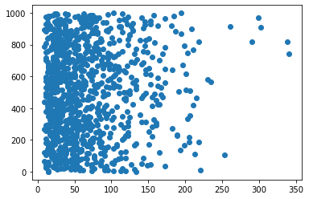

```python
walk_n4 = np.array([len(make_walk(absorbing_barrier=8)) - 1 for i in range(1000)])
w = plt.plot(walk_n4, range(len(walk_n4)), 'o')
```

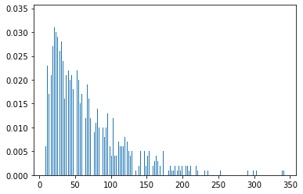

```python
x, fx = np.unique(walk_n4, return_counts=True)
b = plt.bar(x, fx/fx.sum())
```

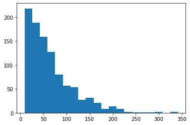

```python
h = plt.hist(walk_n4, bins=20)
```

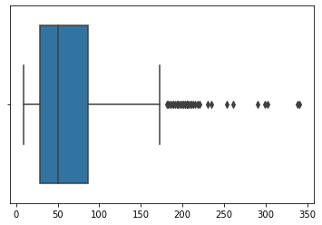

```python
import seaborn as sns
bp = sns.boxplot(walk_n4)
```

**Assignment 5**: What is the minimum and maximum number of steps in 100000 executions when `absorbing_barrier=4`?

```python
def min_max_steps(absorbing_barrier = 4, num_trials = 1000):

    # Crea un vector vacío de tamaño N
    len_walks = np.empty(num_trials, dtype=object)

    for i in range(num_trials):

        # Realiza una simulación del camino aleatorio en una dimensión
        walk = make_walk(absorbing_barrier)

        # Asigna la cantidad de pasos que le tomó llegar a la barrera absorbente
        len_walks[i] = len(walk)

    # Obtiene la mínima cantidad de pasos necesarios para llegar a la barrera absorbente
    min = np.amin(len_walks)

    # Obtiene la máxima cantidad de pasos necesarios para llegar a la barrera absorbente
    max = np.amax(len_walks)

    return [min, max]

min_max_steps(absorbing_barrier = 4, num_trials = 100000)
```

```
[6, 128]
```

**Assignment 6**: Is the behavior observed with `absorbing_barrier=4` the same as the behavior that can be observed with `absorbing_barrier` in `[5, 6, 7, 8]`? What are the main differences and similarities in each case?

Si, el comportamiento observado mediante simulación es similar en los casos cuando la barrera absorbente toma valores de 4, 5, 6, 7 y 8. En general la cantidad de pasos promedio es igual a la función y = x^2, mientras que la cantidad de pasos mínimos es igual a la función y = barrera absorbente + 2

Resultado de varias simulaciones

B. Absorbente --> # mínimo, # máximo

4 --> 6, 192 5 --> 7, 255 6 --> 8, 390 7 --> 9, 479 8 --> 10, 634